# Data Analysis of Severe Weather in USA

Dan K. Hansen

18 April 2016

## Synopsis:

The task at hand is to make a data analysis of the NOAA data set of storm observations over 60+ years from 1950 to November 2011.

Two questions needs to be answered in this analysis:

*1. Across the United States, which types of events (as indicated in the EVTYPE variable) are most harmful with respect to population health?*

*2. Across the United States, which types of events have the greatest economic consequences?*

We will find that **Tornados** and **Floodings** are the most harmful and damaging eventtypes in relation to human impact and crop/property damage in dollars.

We will all so see which top-ten eventtypes are:

- most lethal
- most human injuring
- most crop damageing
- most property damaging

## Data Processing

Used packages:

```r
library(data.table)
library(knitr)
library(ggplot2)
library(gridExtra)
```

I start by downloading the dataset and load it into R This will typically take some time, especially on a Windows system.

[The data set 48MB](https://d396qusza40orc.cloudfront.net/repdata%2Fdata%2FStormData.csv.bz2) [National Weather Service Storm Data Documentation](https://d396qusza40orc.cloudfront.net/repdata%2Fpeer2_doc%2Fpd01016005curr.pdf) [National Climatic Data Center Storm Events](https://d396qusza40orc.cloudfront.net/repdata%2Fpeer2_doc%2FNCDC%20Storm%20Events-FAQ%20Page.pdf)

```r
#Check if dataset file is already present, else download it from the course site:
if (!file.exists("stormdata.csv.bz2")) {
    dlurl <- "https://d396qusza40orc.cloudfront.net/repdata%2Fdata%2FStormData.csv.bz2"
    download.file(dlurl, "stormdata.csv.bz2")
}
#Load the dataset with inline unpacking (Linux only)
if (toupper(Sys.info()["sysname"]) == "LINUX") {
    ds <- fread("bzcat stormdata.csv.bz2")
}
#Load the dataset Windows style
if (toupper(Sys.info()["sysname"]) == "WINDOWS") {
    ds <- read.csv("stormdata.csv.bz2")
}
```

At the time of writing this report, there were 48 NOAA standard eventypes. For convenience I’ve compiled a list with these event types:

```r
#NOAAs 48 standard event types
stdevtype <- read.csv("stdevtype.csv")
stdevtype
```

```
##             NOAA.STD.EVTYPE
## 1     Astronomical Low Tide
## 2                 Avalanche
## 3                  Blizzard
## 4             Coastal Flood
## 5           Cold/Wind Chill
## 6               Debris Flow
## 7                 Dense Fog
## 8               Dense Smoke
## 9                   Drought
## 10               Dust Devil
## 11               Dust Storm
## 12           Excessive Heat
## 13  Extreme Cold/Wind Chill
## 14              Flash Flood
```

[output cut: 34 more lines]

I need to clean the original dataset up a bit, by removing unnecessary variables, modifying the EXP-variables etc. See inline comments for description of the individual code-sections. The conversion of exp is based on this [EXP handling](http://rpubs.com/flyingdisc/PROPDMGEXP)

```r
#We'll reduce the number of columns to use, in order to reduce the memory footprint
usednames <- names(ds)[c(2,8,23:28)]

#This will be our base working dataset
ds1 <- subset(ds,select = usednames)

#Convert BGN_DATE column:
ds1$BGN_DATE <- as.Date(ds1$BGN_DATE[], "%m/%d/%Y %H:%M:%S")

#Remove trailing spaces in EVTYPE:
ds1$EVTYPE <- trimws(ds1$EVTYPE)
#Convert all values to upper-case
ds1$EVTYPE <- toupper(ds1$EVTYPE)

#Check the amount of different values (there are 48 official EVTYPEs)
length(unique(ds1$EVTYPE)) #returns 890 different EVTYPEs !
```

```
## [1] 890
```

```r
#obviously misspelling and other invalid inputs are highly present

#Some cleaning of various typos and abnormal entries, not conclusive
ds1$EVTYPE <- gsub("AVALANCE","AVALANCHE",ds1$EVTYPE)
ds1$EVTYPE <- gsub("GUSTY[[:print:]]","",ds1$EVTYPE)
ds1$EVTYPE <- gsub("WINTER STORM[[:print:]]*|BLOWING SNOW","WINTER STORM",ds1$EVTYPE)
ds1$EVTYPE <- gsub("WINTER WEATHER[[:print:]]*|WINTRY MIX","WINTER WEATHER",ds1$EVTYPE)
ds1$EVTYPE <- gsub("HEAT[[:print:]]*","HEAT",ds1$EVTYPE)
ds1$EVTYPE <- gsub("FLASH FLOOD[[:print:]]*","FLASH FLOOD",ds1$EVTYPE)
ds1$EVTYPE <- gsub("[[:print:]]*FLOOD[[:print:]]*","FLOOD",ds1$EVTYPE)
ds1$EVTYPE <- gsub("HURRICANE[[:print:]]*","HURRICANE",ds1$EVTYPE)
ds1$EVTYPE <- gsub("RIP CURRENT[[:print:]]*","RIP CURRENT",ds1$EVTYPE)
ds1$EVTYPE <- gsub("TSTM","THUNDERSTORM",ds1$EVTYPE)
ds1$EVTYPE <- gsub("THUNDERSTORM[[:print:]]*|THUNDERTORM[[:print:]]*","THUNDERSTORM WIND",ds1$EVTYPE)
ds1$EVTYPE <- gsub("COLD[[:print:]]*","COLD/WIND CHILL",ds1$EVTYPE)
ds1$EVTYPE <- gsub("WILD[[:print:]]*","WILDFIRE",ds1$EVTYPE)
ds1$EVTYPE <- gsub("HIGH SEA[[:print:]]*|HEAVY SURF[[:print:]]*|HEAVY SEA[[:print:]]*|HIGH WA[[:print:]]*|HIGH SW[[:print:]]*","HIGH SURF",ds1$EVTYPE)
ds1$EVTYPE <- gsub("HIGH WI[[:print:]]*|^WINDS$|^WIND$","HIGH WIND",ds1$EVTYPE)
ds1$EVTYPE <- gsub("TROPICAL[[:print:]]*","TROPICAL STORM",ds1$EVTYPE)
ds1$EVTYPE <- gsub("RECORD[[:print:]]","",ds1$EVTYPE)

# Convert CROPDMGEXP and PROPDMGEXP to "real" numbers before aggregating the values!
# reference: http://rpubs.com/flyingdisc/PROPDMGEXP

#Crop first
ds1$CROPDMGEXP[ds1$CROPDMGEXP == ""] <- 0
ds1$CROPDMGEXP <- gsub("[-\\?]", "0", ds1$CROPDMGEXP)
ds1$CROPDMGEXP <- gsub("\\+", "1", ds1$CROPDMGEXP)
ds1$CROPDMGEXP <- gsub("[[:digit:]]", "10", ds1$CROPDMGEXP)
ds1$CROPDMGEXP <- gsub("[Hh]", "100", ds1$CROPDMGEXP)
ds1$CROPDMGEXP <- gsub("[Kk]", "1000", ds1$CROPDMGEXP)
ds1$CROPDMGEXP <- gsub("[Mm]", "1000000", ds1$CROPDMGEXP)
ds1$CROPDMGEXP <- gsub("[Bb]", "1000000000", ds1$CROPDMGEXP)
ds1$CROPDMGEXP <- as.numeric(ds1$CROPDMGEXP)

#And now prop
ds1$PROPDMGEXP[ds1$PROPDMGEXP == ""] <- 0
ds1$PROPDMGEXP <- gsub("[-\\?]", "0", ds1$PROPDMGEXP)
ds1$PROPDMGEXP <- gsub("\\+", "1", ds1$PROPDMGEXP)
ds1$PROPDMGEXP <- gsub("[[:digit:]]", "10", ds1$PROPDMGEXP)
ds1$PROPDMGEXP <- gsub("[Hh]", "100", ds1$PROPDMGEXP)
ds1$PROPDMGEXP <- gsub("[Kk]", "1000", ds1$PROPDMGEXP)
ds1$PROPDMGEXP <- gsub("[Mm]", "1000000", ds1$PROPDMGEXP)
ds1$PROPDMGEXP <- gsub("[Bb]", "1000000000", ds1$PROPDMGEXP)
ds1$PROPDMGEXP <- as.numeric(ds1$PROPDMGEXP)
```

I’m now ready to begin to work with the dataset

```r
#Adding the multipla as a separate columns to aggregate on
ds1 <- cbind(ds1,"CROPDMGxEXP" = ds1$CROPDMG*ds1$CROPDMGEXP)
ds1 <- cbind(ds1,"PROPDMGxEXP" = ds1$PROPDMG*ds1$PROPDMGEXP)

#Joining the total numbers in separate columns to aggregate on
ds1 <- cbind(ds1,"TOTALHARM" = ds1$FATALITIES + ds1$INJURIES)
ds1 <- cbind(ds1,"TOTALDMG" = ds1$CROPDMGxEXP+ds1$PROPDMGxEXP)


#Aggregating by eventtype
dsfatal <- aggregate(ds1$FATALITIES, list(ds1$EVTYPE), FUN = sum)
dsinjury <- aggregate(ds1$INJURIES, list(ds1$EVTYPE), FUN = sum)
dscrop <- aggregate(ds1$CROPDMGxEXP / 1000000, list(ds1$EVTYPE), FUN = sum)
dsprop <- aggregate(ds1$PROPDMGxEXP / 1000000, list(ds1$EVTYPE), FUN = sum)

#And the totals
dsharm <- aggregate(ds1$TOTALHARM, list(ds1$EVTYPE), FUN = sum)
dsdmg <- aggregate(ds1$TOTALDMG / 1000000, list(ds1$EVTYPE), FUN = sum)

#Reducing the aggregated dataset size
dsfatal <- subset(dsfatal,dsfatal$x>0)
dsinjury <- subset(dsinjury,dsinjury$x>0)
dscrop <- subset(dscrop,dscrop$x>0)
dsprop <- subset(dsprop,dsprop$x>0)
dsharm <- subset(dsharm,dsharm$x>0)
dsdmg <- subset(dsdmg,dsdmg$x>0)
```

And now setting up the plots:

```r
#Setting up the plots
toptenfatal <- head(dsfatal[order(dsfatal$x,decreasing = TRUE), ],10)
topteninjury <- head(dsinjury[order(dsinjury$x, decreasing = TRUE), ],10)
toptencrop <- head(dscrop[order(dscrop$x, decreasing = TRUE), ],10)
toptenprop <- head(dsprop[order(dsprop$x, decreasing = TRUE), ],10)
topfiveharm <- head(dsharm[order(dsharm$x, decreasing = TRUE), ],5)
topfivedmg <- head(dsdmg[order(dsdmg$x, decreasing = TRUE), ],5)
```

## Results

The result of the analysis is self explanatory:

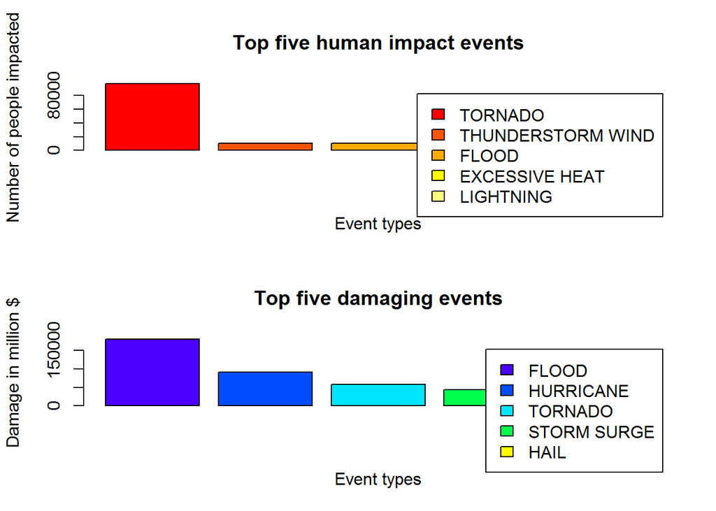

```r
#Using basic plot system for the summary
par(mfrow=c(2, 1))
barplot(topfiveharm[,2],col=heat.colors(5),main = "Top five human impact events",legend.text = topfiveharm[,1],ylab = "Number of people impacted",xlab = "Event types")
barplot(topfivedmg[,2],col=topo.colors(5),main = "Top five damaging events", legend.text = topfivedmg[,1],ylab = "Damage in million $",xlab = "Event types")
```

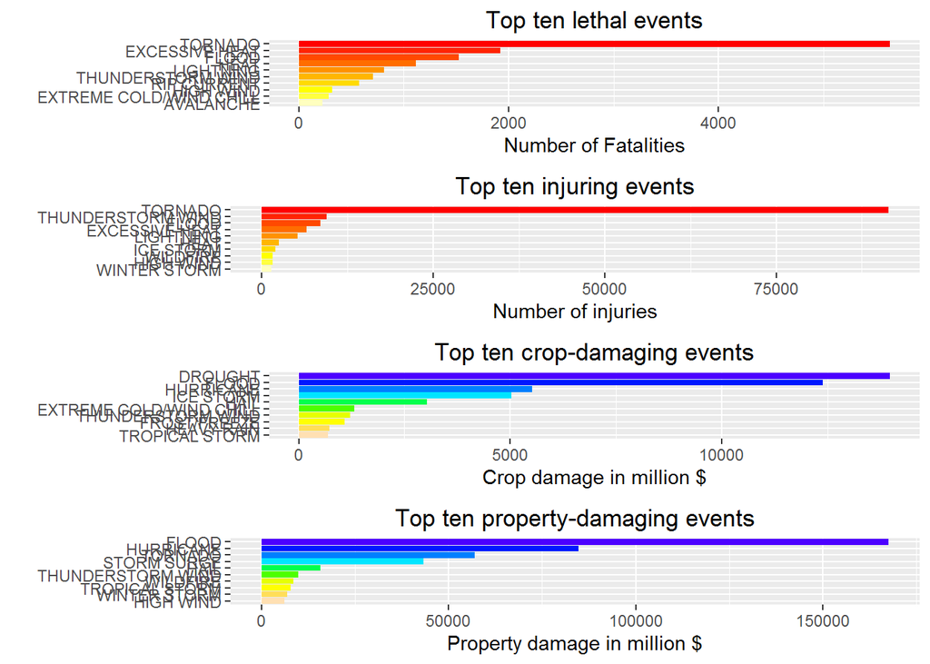

```r
#Setting up top-ten plots
p1 <-ggplot(toptenfatal, aes(x=factor(toptenfatal$Group.1, levels = rev(toptenfatal$Group.1[])), y=toptenfatal$x)) +
        geom_bar(stat="identity", fill = rev(heat.colors((10)))) +
        coord_flip() +
        xlab("") +
        ylab("Number of Fatalities") +
        ggtitle("Top ten lethal events")

p2 <-ggplot(topteninjury, aes(x=factor(topteninjury$Group.1, levels = rev(topteninjury$Group.1[])), y=topteninjury$x)) +
        geom_bar(stat="identity", fill = rev(heat.colors((10)))) +
        coord_flip() +
        xlab("") +
        ylab("Number of injuries") +
        ggtitle("Top ten injuring events")

p3 <-ggplot(toptencrop, aes(x=factor(toptencrop$Group.1, levels = rev(toptencrop$Group.1[])), y=toptencrop$x)) +
        geom_bar(stat="identity", fill = rev(topo.colors((10)))) +
        coord_flip() +
        xlab("") +
        ylab("Crop damage in million $") +
        ggtitle("Top ten crop-damaging events")

p4 <-ggplot(toptenprop, aes(x=factor(toptenprop$Group.1, levels = rev(toptenprop$Group.1[])), y=toptenprop$x)) +
        geom_bar(stat="identity", fill = rev(topo.colors((10)))) +
        coord_flip() +
        xlab("") +
        ylab("Property damage in million $") +
        ggtitle("Top ten property-damaging events")

#Using package gridExtra to arrange plots
grid.arrange(p1, p2, p3, p4, ncol=1)
```